# BMIN503/EPID600 Project Template

James Gesualdi

### Overview

My project will be a limited meta-analysis of existing bulk RNAseq data sets detailing the differentiation of induced-pluripotent stem cells (IPSCs) into microglia, a key population of resident immune cells in the central nervous system (CNS). IPSC-based modeling is the future of microglia biology in vitro, thus there are many competing standards - eg different IPSC-derived microglia produced by different groups. My analysis will compare the transcriptomes of these competing microglia to a “Gold Standard” or reference transcriptomic dataset generated using microglia isolated from post-mortem biopsies from human donors.

Project Repository: https://github.com/gesualdiJ/BMIN503_Final_Project

### Introduction

Microglia have long been challenging to model in-vitro using conventional approaches such as immortalized cell lines or primary culture because their morphology, function, and (more recently appreciated) transcriptome rapidly deteriorate when cultured in isolation. To address this issue, numerous groups have developed microglial cell lines derived from IPSCs through supplementation of cultures with various factors normally present in the micro-encironment of the CNS. The goal of this project is to interrogte the merit of several published IPSC-derived microglia lines along with some more recently developed applications of these cells involving chimeric animal model systems.

Addressing this problem involves suject matter knowledge of both immunology and neuroscience, as well as various bioinformatic techniques. This analysis will include only a subset of published microglial lines, prioritizing those models that myself and Drs Schaletzki and Su considered influential. The reference transcriptomes - one from adult donors and one generated from analysis of pediatric tissue - add rigor to this project because they represent the closest that we can realistically hope to get to the in vivo gene expression of microglia. The microglia that were analyzed to generate these reference transcriptomes were isolated immediately after surgical resection from patients, therefore there has been minimal time for these cells to lose their in vivo character. Finally, this analysis will be useful to microglia biologists because while many transcriptomic data sets exist, there have been few if any comprehensive meta-analyses of these data and still fewer attempts to harmonize their insights. This project aims to make progress in that direction.

### Methods

#install and load packages—-

```r
install.packages("BiocManager")
BiocManager::install(c("GEOquery",
                       "oligo",
                       "limma",
                       "hgu133plus2.db",
                       "pd.hg.u133.plus.2",
                       "viridis",
                       "fgsea",
                       "edgeR",
                       "gplots"))
install.packages("tidyverse")
install.packages("reshape2")
install.packages("edgeR")
install.packages("readxl")
install.packages("ggplot2")
install.packages("fgsea")
install.packages("stringr")
install.packages("readr")
install.packages("purrr")
BiocManager::install("ensembldb")
BiocManager::install("AnnotationHub")
BiocManager::install("rhdf5")
```

```r
library(BiocManager)
library(tidyverse)
library(reshape2)
library(rhdf5)
library(edgeR)
library(readxl)
library(GEOquery)
library(oligo)
library(limma)
library(viridis)
library(pd.hg.u133.plus.2)
library(hgu133plus2.db)
library(ggplot2)
library(gplots)
library(fgsea)
library(stringr)
library(readr)
library(ensembldb)
library(AnnotationHub)
library(purrr)
```

```r
#Gosselin Data, Fetal Ex-Vivo iMg (raw reads, needs cleaning (removing all non Ex-Vivo microglia conditions) and filtering (removing non-expressed genes) and normalizing (TPM))----

#This Reference dataset contains 24  ex-vivo microglia samples from 24 pediatric patients isolated following surgical resection
#The number of observations (expressed genes) for this dataset is 14,528
#The processed data frames containing these data are stored in tbl's "ExVivo_Juvenile_MG_Reference_Gosselin" (no GeneID column, gene names are row names)
#or "Gosselin_log2_cpm_filtered_norm" (maintains GeneID as a separate column)

#These data are published but the .xlsx file containing the raw counts, sample labels, and gene names were sent to me by a collaborator
#Therefore, I can just read the counts into a data frame and begin cleaning, filtering, and normalizing without having to access any
#Transcriptomic repositories or databases. That makes the processing for this data set simpler but less generalizeable. The following
#Datasets make use of either EnsembleDB or ArchS4 and are therefore more informative for directly accessing published data without any personal connections.


microglia_fetal_ExVivo_Gosselin <- read_xlsx("Human_RNA-seq_data_Gosselin_Fetal_ExVivo.xlsx", sheet = 1, skip = 1) #Read in raw counts
microglia_fetal_ExVivo_Gosselin <- dplyr::rename(microglia_fetal_ExVivo_Gosselin, Gene_ID = ...1)
microglia_fetal_ExVivo_Gosselin <- microglia_fetal_ExVivo_Gosselin[!duplicated(microglia_fetal_ExVivo_Gosselin$Gene_ID), ]  #remove any duplicated genes symbols (2)
microglia_fetal_ExVivo_Gosselin <- column_to_rownames(microglia_fetal_ExVivo_Gosselin, var = "Gene_ID") #Move gene labels from column to rowname to allow for math operations on values

microglia_fetal_ExVivo_Gosselin <- microglia_fetal_ExVivo_Gosselin %>%
  dplyr::select(!contains("InVitro") & !contains("Monocytes") & !contains("Lysate"))  #Removes 40 columns of unneeded monocyte/in vitro/lysate data
sample_Labels_Gosselin <- colnames(microglia_fetal_ExVivo_Gosselin)


DGEList_Gosselin <- DGEList(microglia_fetal_ExVivo_Gosselin) #Convert to DGE list to facilitate normalization and count visualization
Gosselin_cpm <- cpm(DGEList_Gosselin$counts)                #Get counts per million for count visualization and filtering of unexpressed genes
table(rowSums(DGEList_Gosselin$counts==0)==24)              #Shows number of non-expressed genes across all samples, indicates roughly how many should be filtered out
```

```
##
## FALSE  TRUE
## 22061  2750
```

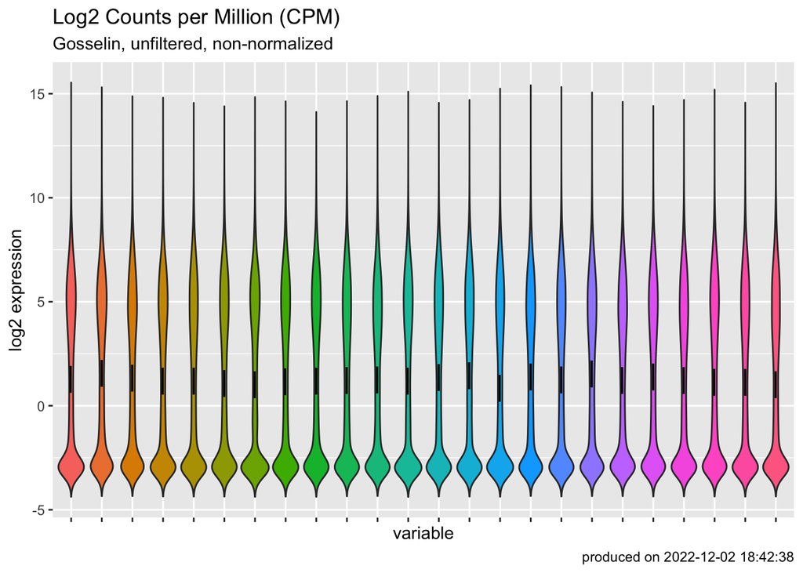

```r
Gosselin_log2_cpm <- as_tibble(cpm(DGEList_Gosselin$counts, log = TRUE) , rownames = "GeneID") #Create and reshape (melt) tibble of log transformed raw counts to visualized unfiltered / unnormalized data
Gosselin_log2_cpm_melt <- melt(Gosselin_log2_cpm)

ggplot(Gosselin_log2_cpm_melt, aes(x=variable, y=value, fill=variable)) +     #visualize overall expression to show excessive influence of unexpressed / lowly expressed genes
  geom_violin(trim = FALSE, show.legend = FALSE) +
  stat_summary(fun.y = "median",
               geom = "point",
               shape = 124,
               size = 6,
               color = "black",
               show.legend = FALSE) +
  theme(axis.text.x=element_blank()) +
  labs(y="log2 expression",
       title="Log2 Counts per Million (CPM)",
       subtitle="Gosselin, unfiltered, non-normalized",
       caption=paste0("produced on ", Sys.time()))
```

```r
filtrate_gosselin <- rowSums(Gosselin_cpm > 1) >= 6  #create logical vector that evaluates to TRUE when at least 6 of 24 samples express a given gene
table(filtrate_gosselin)
```

```
## filtrate_gosselin
## FALSE  TRUE
## 10283 14528
```

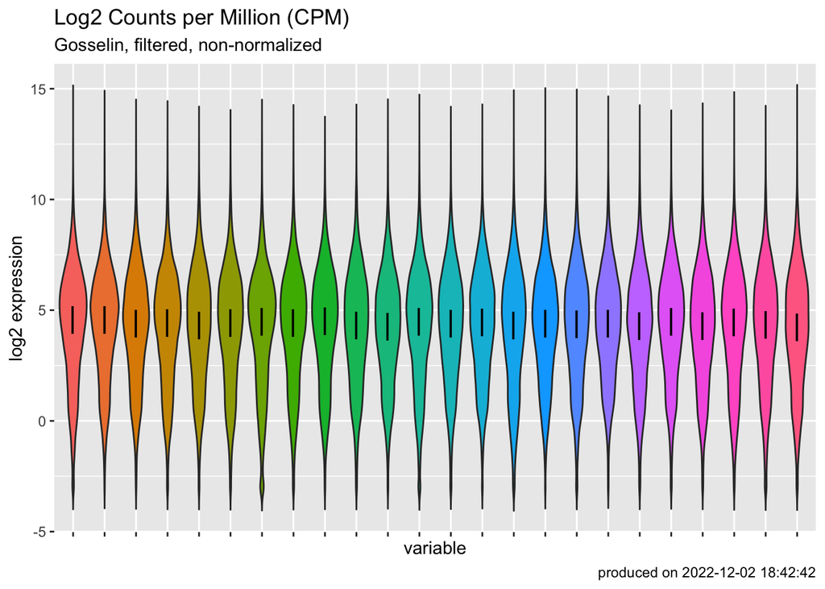

```r
DGEList_Gosselin_filtered <- DGEList_Gosselin[filtrate_gosselin, ] #subset DGE list so that only genes expressed in at least 6 samples remain
Gosselin_log2_cpm_filtered <- as_tibble(cpm(DGEList_Gosselin_filtered, log = TRUE), rownames = "GeneID") #get counts per million with log2 transformation, reshape and visualize

Gosselin_log2_cpm_filtered_melt <- melt(Gosselin_log2_cpm_filtered)
ggplot(Gosselin_log2_cpm_filtered_melt, aes(x=variable, y=value, fill=variable)) +
  geom_violin(trim = FALSE, show.legend = FALSE) +
  stat_summary(fun.y = "median",
               geom = "point",
               shape = 124,
               size = 6,
               color = "black",
               show.legend = FALSE) +
  theme(axis.text.x=element_blank()) +
  labs(y="log2 expression",
       title="Log2 Counts per Million (CPM)",
       subtitle="Gosselin, filtered, non-normalized",
       caption=paste0("produced on ", Sys.time()))
```

```r
DGEList_Gosselin_filtered_norm <- calcNormFactors(DGEList_Gosselin_filtered, method = "TMM") #TPM normalization
Gosselin_log2_cpm_filtered_norm <- as_tibble(cpm(DGEList_Gosselin_filtered_norm, log = TRUE), rownames = "GeneID") #Format maintaining GeneID column if needed for join function
ExVivo_Juvenile_MG_Reference_Gosselin <- column_to_rownames(Gosselin_log2_cpm_filtered_norm, var = "GeneID") #Final format of juvenile (J) microglia reference data

labels_Gosselin <- rep(NA, 24)  #clean up lengthy sample labels for this dataset. haters will suggest rewriting with vapply. I will never learn vapply!
i <- 1

while (i <= 24){
  labels_Gosselin[i] = paste0(paste0("J", substring(sample_Labels_Gosselin[i], 16, 32)), as.character(i))
  i = i + 1
}
colnames(ExVivo_Juvenile_MG_Reference_Gosselin) <- labels_Gosselin
```

```r
#Eggen Data, Adult Ex-Vivo iMg from surgical resection, 39 total samples----

##This processed Reference dataset will contain 39 total samples (all Ex Vivo microglia surgically resected from adult patients)
#The number of observations (expressed genes) for this dataset is 14,397
#The processed data frames containing these data are stored in tbl's "ExVivo_Adult_MG_Reference_Eggen" (no GeneID column, gene names are row names)
#or "Eggen_log2_cpm_filtered_norm" (maintains GeneID as a separate column)

#This dataset was accessed by directly downloading the tsv containing the raw counts from GEO. However, these data contained only
#transcript IDs instead of gene names like the other datasets. Therefore, I needed to use AnnotationHub() to access the Ensemble Data base
#in order to map the transcript IDs to the appropriate gene names. This is comparable to the use of hgu133plus2.db in Practicum 9,
#But is optimized for Bulk RNA sequencing data rather than MicroArrays, which are somewhat out of date (no shade)

#This is an alternative approach to using the ArchS4 database, which I employ for the next 3 datasets. This
#Method was mainly included to showcase alternate approaches to access GEO data without downloading and reading in the  large (16 GB!) Archs4 database
#This is also a more beginner friendly approach that allows the user to avoid working with the somewhat cumbersome HDF5 files that ArchS4 uses to organize data


ah <- AnnotationHub()
ahDb <- query(ah, pattern = c("Homo Sapiens", "EnsDb"))   ## Query for available H.Sapiens EnsDb databases, using for mapping probe id's to gene names
EndDB_Hs <- ahDb[["AH104864"]]
EnsDB_Hs <- EndDB_Hs
EnsDB_Hs_DF <- genes(EnsDB_Hs, return.type = "data.frame") %>%
  dplyr::select(gene_id, gene_name)
EnsDB_Hs_DF <- dplyr::rename(EnsDB_Hs_DF, Tx_ID = gene_id)

microglia_adult_ExVivo_Eggen <- read_tsv("GSE99074_HumanMicrogliaBrainCounts.txt")       #read in data, will need to add gene names using EnsDB information
microglia_adult_ExVivo_Eggen <- dplyr::rename(microglia_adult_ExVivo_Eggen, Tx_ID = ...1)

EnsDB_Hs_DF <- dplyr::filter(EnsDB_Hs_DF, EnsDB_Hs_DF$Tx_ID %in% microglia_adult_ExVivo_Eggen$Tx_ID)  #subset list of matched tx_id's and gene names to only include tx's present in dataset
microglia_adult_ExVivo_Eggen <- inner_join(microglia_adult_ExVivo_Eggen, EnsDB_Hs_DF, by = "Tx_ID")
microglia_adult_ExVivo_Eggen <- relocate(microglia_adult_ExVivo_Eggen, gene_name, .before = spm09)
microglia_adult_ExVivo_Eggen <- microglia_adult_ExVivo_Eggen[ , 1:67]
microglia_adult_ExVivo_Eggen <- dplyr::rename(microglia_adult_ExVivo_Eggen, GeneID = gene_name)
table(microglia_adult_ExVivo_Eggen$GeneID == "") #5116 transcripts ID's for which there is no corresponding gene name, we remove using dplyr::filter
```

```
##
## FALSE  TRUE
## 22721  5116
```

```r
microglia_adult_ExVivo_Eggen <- dplyr::filter(microglia_adult_ExVivo_Eggen, GeneID != "")
microglia_adult_ExVivo_Eggen <- microglia_adult_ExVivo_Eggen[ , 2:67]
microglia_adult_ExVivo_Eggen <- microglia_adult_ExVivo_Eggen[1:40]
microglia_adult_ExVivo_Eggen <- microglia_adult_ExVivo_Eggen[!duplicated(microglia_adult_ExVivo_Eggen$GeneID), ]
microglia_adult_ExVivo_Eggen <- column_to_rownames(microglia_adult_ExVivo_Eggen, var = "GeneID")

#Create DGElist, find counts per million, visualize distribution of data, and filter out unexpressed probes
DGEList_Eggen <- DGEList(microglia_adult_ExVivo_Eggen)      #Convert to DGE list to facilitate normalization and count visualization
Eggen_cpm <- cpm(DGEList_Eggen)                #Get counts per million for count visualization and filtering of unexpressed genes
table(rowSums(DGEList_Eggen$counts==0)==20)              #Shows number of non-expressed genes across all samples, indicates roughly how many should be filtered out
```

```
##
## FALSE  TRUE
## 22270   237
```

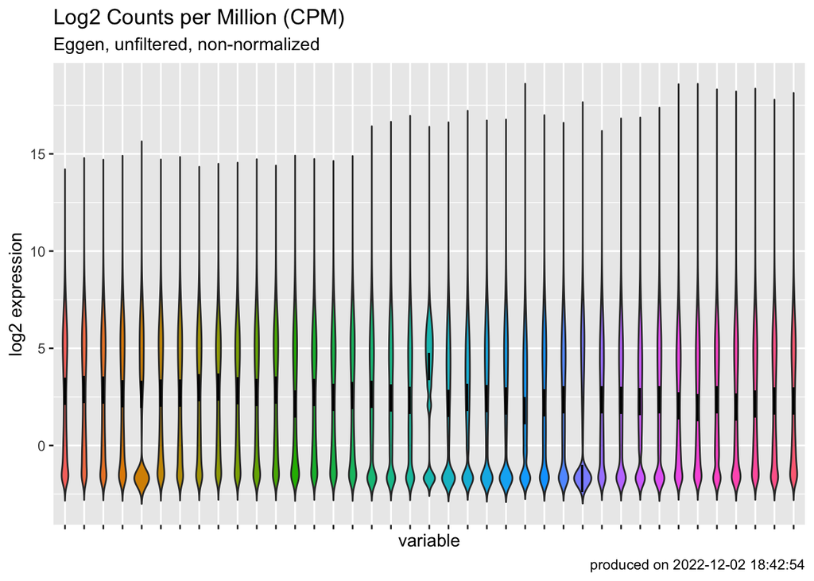

```r
Eggen_log2_cpm <- as_tibble(cpm(DGEList_Eggen, log = TRUE) , rownames = "GeneID") #Create and reshape (melt) tibble of log transformed raw counts to visualized unfiltered / unnormalized data
Eggen_log2_cpm_melt <- melt(Eggen_log2_cpm)

ggplot(Eggen_log2_cpm_melt, aes(x=variable, y=value, fill=variable)) +     #visualize overall expression to show excessive influence of unexpressed / lowly expressed genes
  geom_violin(trim = FALSE, show.legend = FALSE) +
  stat_summary(fun.y = "median",
               geom = "point",
               shape = 124,
               size = 6,
               color = "black",
               show.legend = FALSE) +
  theme(axis.text.x=element_blank()) +
  labs(y="log2 expression",
       title="Log2 Counts per Million (CPM)",
       subtitle="Eggen, unfiltered, non-normalized",
       caption=paste0("produced on ", Sys.time()))
```